# HowToInvadeTheOccupiedNiche_Analyses

Mathias Wegner, AWI

07/01/2022

## R Markdown

This is an R Markdown of the analyses accompanying the manuscript ‘Invading the occupied niche: aggregation behavior gives a generalist parasite the edge over an established specialist’ by Marieke E. Feis, Leo Gottschalck, Lena Ruf, Franziska Theising, Felicitas Demann, K. Mathias Wegner.

Functions:

```r
#defining standard error
se = function(x)
{
    sd(x, na.rm=T)/sqrt(length(x))
}

#perform phase shift analysis
# parameters:
# x, y: numeric vectors for shifted correlation calucation
# left_shift, right_shift: integers for how many intervals series will be pushed left and right
# value:
# a list 1) R2: numric vector of all observed R2 values and 2) models: a list of the corresponding linear models
calcPhaseShift = function(x,y,left_shift,right_shift)
{

  models = list() #list of linear models for each time shift
  R2 = vector(mode = 'numeric') #vector of the correponding R2-values

  for(i in left_shift:right_shift)
  {
    if(i<0)
    {
      this.x = x[1:(length(x)-abs(i))]
      this.y = y[(abs(i)+1):length(y)]
    }
    if(i==0)
    {
      this.x = x
      this.y = y
    }


    if(i>0)
    {
      this.x = x[(abs(i)+1):length(x)]
      this.y = y[1:(length(y)-abs(i))]
    }

    mod = lm(this.x~this.y)
    modname = paste('mod',i,sep='_')
    models[[length(models)+1]] <- mod
    #print(summary(mod))
    R2 = c(R2,summary(mod)$r.squared)

    #rho = cor.test(x,y, method = 'spearman')
    #Rho = c(Rho,rho$estimate)

  }
  return(list(R2=R2,models=models))
}
```

## PART I: Field data

This part analyses the field data collected in Königshafen from 2013 until 2019.

Phase shift calculations for Figure 1C,D

```r
#reducing data set to times of co-occurence
after2015 = subset(M_Mint_prev, M_Mint_prev$Year>2015)

#phase shift
x_phase = -3:4
MintMori_shift = calcPhaseShift(after2015$M_infected_Mint,after2015$M_infected_Mori,-3,4)
bestMod_Index = which(MintMori_shift$R2==max(MintMori_shift$R2))
bestMod = MintMori_shift$models[[bestMod_Index]]
print(paste('Best correlation at shift:',x_phase[bestMod_Index]))
```

```
## [1] "Best correlation at shift: 1"
```

```r
summary(bestMod)
```

```
##
## Call:
## lm(formula = this.x ~ this.y)
##
## Residuals:
##      Min       1Q   Median       3Q      Max
## -0.16786 -0.11268  0.02769  0.10247  0.15117
##
## Coefficients:
##             Estimate Std. Error t value Pr(>|t|)
## (Intercept)  0.93786    0.08005  11.716 2.57e-06 ***
## this.y      -0.71832    0.24064  -2.985   0.0175 *
## ---
## Signif. codes:  0 '***' 0.001 '**' 0.01 '*' 0.05 '.' 0.1 ' ' 1
##
## Residual standard error: 0.127 on 8 degrees of freedom
## Multiple R-squared:  0.5269, Adjusted R-squared:  0.4678
## F-statistic:  8.91 on 1 and 8 DF,  p-value: 0.01747
```

Plot Figure 1 B,C,D

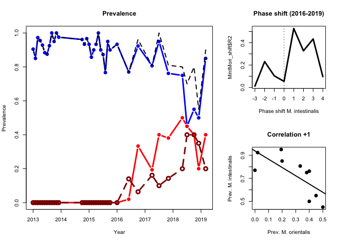

Calculate dispersion and reproductive opportunities ‘M_Mint_abundance’ is a sampling interval aggregate of M. intestinalis (Mint) abundances in mussels (M), Mori is M. orientalis, and O is oyster. Different stats are calculated for each host parasite combination (M_Mint, M_mori, O_Mori) For all 3 combinations data is merged into M-Mint_abundance

Analysis for Figure 2B: Aggregation in different parasite-host combinations

```r
#analysis
#test for species differences accounting for different variances
fit.gls <- gls(varToMean~hostPar, weights = varIdent(form = ~ 1 | hostPar), data = disp)
summary(fit.gls)
```

```
## Generalized least squares fit by REML
##   Model: varToMean ~ hostPar
##   Data: disp
##      AIC      BIC   logLik
##   228.77 240.5917 -108.385
##
## Variance function:
##  Structure: Different standard deviations per stratum
##  Formula: ~1 | hostPar
##  Parameter estimates:
##   M_Mint   M_Mori   O_Mori
## 1.000000 0.305492 5.467188
##
## Coefficients:
##                   Value Std.Error   t-value p-value
## (Intercept)    2.971621 0.2644636 11.236411  0.0000
## hostParM_Mori -0.980940 0.3056782 -3.209060  0.0023
## hostParO_Mori  5.074641 2.7560675  1.841262  0.0712
##
##  Correlation:
##               (Intr) hsPM_M
## hostParM_Mori -0.865
## hostParO_Mori -0.096  0.083
##
## Standardized residuals:
##        Min         Q1        Med         Q3        Max
## -1.2646412 -0.6527898 -0.3029589  0.3602025  2.7727779
##
## Residual standard error: 1.586781
## Degrees of freedom: 56 total; 53 residual
```

```r
anova(fit.gls)
```

```
## Denom. DF: 53
##             numDF   F-value p-value
## (Intercept)     1 288.73189  <.0001
## hostPar         2   7.38559  0.0015
```

Analysis Figure 2C: Chances of encountering a mate

```r
#### prop Repro 2C
#regression before M. orientalis arrival in 2016
M_Mint_abundance_before = subset(M_Mint_abundance,M_Mint_abundance$x_month < 35)
M_Mint_abundance_after = subset(M_Mint_abundance,M_Mint_abundance$x_month > 35)

M_mint_repro_mod_before = lm(M_Mint_abundance_before$repro_M_Mint~ M_Mint_abundance_before$x_month)
print(summary(M_mint_repro_mod_before))
```

```
##
## Call:
## lm(formula = M_Mint_abundance_before$repro_M_Mint ~ M_Mint_abundance_before$x_month)
##
## Residuals:
##       Min        1Q    Median        3Q       Max
## -0.143510 -0.044232  0.000878  0.057360  0.114619
##
## Coefficients:
##                                   Estimate Std. Error t value Pr(>|t|)
## (Intercept)                      0.8289533  0.0270430   30.65   <2e-16 ***
## M_Mint_abundance_before$x_month -0.0004377  0.0012878   -0.34    0.737
## ---
## Signif. codes:  0 '***' 0.001 '**' 0.01 '*' 0.05 '.' 0.1 ' ' 1
##
## Residual standard error: 0.07296 on 23 degrees of freedom
## Multiple R-squared:  0.004998,   Adjusted R-squared:  -0.03826
## F-statistic: 0.1155 on 1 and 23 DF,  p-value: 0.737
```

```r
M_mint_repro_mod_after = lm(M_Mint_abundance_after$repro_M_Mint~ M_Mint_abundance_after$x_month)
print(summary(M_mint_repro_mod_after))
```

```
##
## Call:
## lm(formula = M_Mint_abundance_after$repro_M_Mint ~ M_Mint_abundance_after$x_month)
##
## Residuals:
##       Min        1Q    Median        3Q       Max
## -0.178387 -0.115694 -0.008255  0.068842  0.308812
##
## Coefficients:
##                                 Estimate Std. Error t value Pr(>|t|)
## (Intercept)                     1.118737   0.225927   4.952 0.000789 ***
## M_Mint_abundance_after$x_month -0.009723   0.003800  -2.559 0.030751 *
## ---
## Signif. codes:  0 '***' 0.001 '**' 0.01 '*' 0.05 '.' 0.1 ' ' 1
##
## Residual standard error: 0.1542 on 9 degrees of freedom
## Multiple R-squared:  0.4211, Adjusted R-squared:  0.3568
## F-statistic: 6.547 on 1 and 9 DF,  p-value: 0.03075
```

```r
M_mori_repro_mod = lm(repro_M_Mori~x_month, data = M_Mint_abundance)
print(summary(M_mori_repro_mod))
```

```
##
## Call:
## lm(formula = repro_M_Mori ~ x_month, data = M_Mint_abundance)
##
## Residuals:
##      Min       1Q   Median       3Q      Max
## -0.14607 -0.05226  0.02803  0.04729  0.11193
##
## Coefficients:
##              Estimate Std. Error t value Pr(>|t|)
## (Intercept) -0.161838   0.148774  -1.088  0.30836
## x_month      0.009051   0.002429   3.726  0.00582 **
## ---
## Signif. codes:  0 '***' 0.001 '**' 0.01 '*' 0.05 '.' 0.1 ' ' 1
##
## Residual standard error: 0.08245 on 8 degrees of freedom
##   (26 observations deleted due to missingness)
## Multiple R-squared:  0.6344, Adjusted R-squared:  0.5887
## F-statistic: 13.88 on 1 and 8 DF,  p-value: 0.00582
```

```r
O_mori_repro_mod = lm(repro_O_Mori~x_month, data = M_Mint_abundance)
print(summary(O_mori_repro_mod))
```

```
##
## Call:
## lm(formula = repro_O_Mori ~ x_month, data = M_Mint_abundance)
##
## Residuals:
##      Min       1Q   Median       3Q      Max
## -0.52545 -0.06460  0.03812  0.12121  0.24152
##
## Coefficients:
##              Estimate Std. Error t value Pr(>|t|)
## (Intercept) -0.502173   0.409559  -1.226   0.2550
## x_month      0.018684   0.006687   2.794   0.0234 *
## ---
## Signif. codes:  0 '***' 0.001 '**' 0.01 '*' 0.05 '.' 0.1 ' ' 1
##
## Residual standard error: 0.227 on 8 degrees of freedom
##   (26 observations deleted due to missingness)
## Multiple R-squared:  0.4939, Adjusted R-squared:  0.4306
## F-statistic: 7.807 on 1 and 8 DF,  p-value: 0.02341
```

Plotting of Figure 2

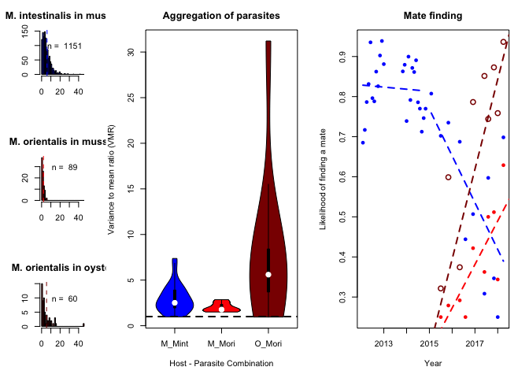

## Part II: Simultaneous and Sequential infections (Fig 3A)

This part analyses the simultaneous and sequential infection data, corresponding to Figure 3 ### Simultaneous infections (Fig 3A)

```r
#############################################################################################################
# test by binomial GLMM
#############################################################################################################

mod = glmer(cbind(Parasite_count,(exposureDose-Parasite_count))~Parasite * treatment + (1|Mussel_name), data = dataSim, family = 'binomial',control=glmerControl(optimizer="bobyqa",optCtrl=list(maxfun=2e5)))
print(summary(mod))
```

```
## Generalized linear mixed model fit by maximum likelihood (Laplace
##   Approximation) [glmerMod]
##  Family: binomial  ( logit )
## Formula: cbind(Parasite_count, (exposureDose - Parasite_count)) ~ Parasite *
##     treatment + (1 | Mussel_name)
##    Data: dataSim
## Control: glmerControl(optimizer = "bobyqa", optCtrl = list(maxfun = 2e+05))
##
##      AIC      BIC   logLik deviance df.resid
##    256.8    266.3   -123.4    246.8       45
##
## Scaled residuals:
##     Min      1Q  Median      3Q     Max
## -2.1495 -0.2840  0.0019  0.2957  3.1996
##
## Random effects:
##  Groups      Name        Variance Std.Dev.
##  Mussel_name (Intercept) 0.8514   0.9227
## Number of obs: 50, groups:  Mussel_name, 37
##
## Fixed effects:
##                           Estimate Std. Error z value Pr(>|z|)
## (Intercept)                0.04151    0.31002   0.134    0.893
## ParasiteMori              -1.95992    0.30020  -6.529 6.64e-11 ***
## treatmentinf              -0.11576    0.42047  -0.275    0.783
## ParasiteMori:treatmentinf  0.07179    0.53450   0.134    0.893
## ---
## Signif. codes:  0 '***' 0.001 '**' 0.01 '*' 0.05 '.' 0.1 ' ' 1
##
## Correlation of Fixed Effects:
##             (Intr) PrstMr trtmnt
## ParasiteMor -0.333
## treatmentnf -0.737  0.247
## PrstMr:trtm  0.186 -0.545 -0.496
```

```r
#############################################################################################################
# pairwise comparisons
#############################################################################################################
dataSim$PxT = interaction(dataSim$Parasite,dataSim$treatment)
compMod = glmer(cbind(Parasite_count,(exposureDose-Parasite_count))~PxT + (1|Mussel_name), data = dataSim, family = 'binomial',control=glmerControl(optimizer="bobyqa",optCtrl=list(maxfun=2e5)))
print(summary(compMod))
```

```
## Generalized linear mixed model fit by maximum likelihood (Laplace
##   Approximation) [glmerMod]
##  Family: binomial  ( logit )
## Formula: cbind(Parasite_count, (exposureDose - Parasite_count)) ~ PxT +
##     (1 | Mussel_name)
##    Data: dataSim
## Control: glmerControl(optimizer = "bobyqa", optCtrl = list(maxfun = 2e+05))
##
##      AIC      BIC   logLik deviance df.resid
##    256.8    266.3   -123.4    246.8       45
##
## Scaled residuals:
##     Min      1Q  Median      3Q     Max
## -2.1495 -0.2840  0.0019  0.2957  3.1996
##
## Random effects:
##  Groups      Name        Variance Std.Dev.
##  Mussel_name (Intercept) 0.8514   0.9227
## Number of obs: 50, groups:  Mussel_name, 37
##
## Fixed effects:
##               Estimate Std. Error z value Pr(>|z|)
## (Intercept)    0.04151    0.31002   0.134    0.893
## PxTMori.coinf -1.95992    0.30020  -6.529 6.64e-11 ***
## PxTMint.inf   -0.11576    0.42047  -0.275    0.783
## PxTMori.inf   -2.00388    0.46620  -4.298 1.72e-05 ***
## ---
## Signif. codes:  0 '***' 0.001 '**' 0.01 '*' 0.05 '.' 0.1 ' ' 1
##
## Correlation of Fixed Effects:
##             (Intr) PxTMr.c PxTMn.
## PxTMori.cnf -0.333
## PxTMint.inf -0.737  0.247
## PxTMori.inf -0.666  0.242   0.493
```

```r
print(summary(glht(compMod, linfct = mcp(PxT = 'Tukey'))))
```

```
##
##   Simultaneous Tests for General Linear Hypotheses
##
## Multiple Comparisons of Means: Tukey Contrasts
##
##
## Fit: glmer(formula = cbind(Parasite_count, (exposureDose - Parasite_count)) ~
##     PxT + (1 | Mussel_name), data = dataSim, family = "binomial",
##     control = glmerControl(optimizer = "bobyqa", optCtrl = list(maxfun = 2e+05)))
##
## Linear Hypotheses:
##                              Estimate Std. Error z value Pr(>|z|)
## Mori.coinf - Mint.coinf == 0 -1.95992    0.30020  -6.529  < 1e-04 ***
## Mint.inf - Mint.coinf == 0   -0.11576    0.42047  -0.275 0.992431
## Mori.inf - Mint.coinf == 0   -2.00388    0.46620  -4.298  < 1e-04 ***
## Mint.inf - Mori.coinf == 0    1.84416    0.45229   4.077 0.000244 ***
## Mori.inf - Mori.coinf == 0   -0.04397    0.48955  -0.090 0.999730
## Mori.inf - Mint.inf == 0     -1.88812    0.44834  -4.211 0.000141 ***
## ---
## Signif. codes:  0 '***' 0.001 '**' 0.01 '*' 0.05 '.' 0.1 ' ' 1
## (Adjusted p values reported -- single-step method)
```

```r
meanInf = aggregate( infRate2 ~ treatment*Parasite, data = dataSim, mean)
meanSE = aggregate( infRate2 ~ treatment*Parasite, data = dataSim, se)
```

### Sequential Infections (Fig 3B)

```r
#############################################################################################################
# test by binomial GLMM
#############################################################################################################

modSeq = glmer(cbind(inf,(dose-inf))~ Parasite * round * HomHet + (1|Mussel), data = dataSeq, family = 'binomial',control=glmerControl(optimizer="bobyqa",optCtrl=list(maxfun=2e5)))
#summary(modSeq)
Anova(modSeq, type = 'III')
```

```
## Analysis of Deviance Table (Type III Wald chisquare tests)
##
## Response: cbind(inf, (dose - inf))
##                         Chisq Df Pr(>Chisq)
## (Intercept)            7.6926  1  0.0055448 **
## Parasite               7.4328  1  0.0064045 **
## round                 12.1246  1  0.0004976 ***
## HomHet                 0.2241  2  0.8940092
## Parasite:round         1.4622  1  0.2265838
## Parasite:HomHet        3.5664  2  0.1680971
## round:HomHet           3.6268  2  0.1631009
## Parasite:round:HomHet 10.0288  2  0.0066417 **
## ---
## Signif. codes:  0 '***' 0.001 '**' 0.01 '*' 0.05 '.' 0.1 ' ' 1
```

### Pairwise comparisons of Sequential infections

```
## Generalized linear mixed model fit by maximum likelihood (Laplace
##   Approximation) [glmerMod]
##  Family: binomial  ( logit )
## Formula: cbind(inf, (dose - inf)) ~ PxRxHH + (1 | Mussel)
##    Data: dataSeq
## Control: glmerControl(optimizer = "bobyqa", optCtrl = list(maxfun = 2e+05))
##
##      AIC      BIC   logLik deviance df.resid
##    667.5    698.2   -322.8    645.5      109
##
## Scaled residuals:
##     Min      1Q  Median      3Q     Max
## -2.5314 -0.8444 -0.1775  0.6842  2.8013
##
## Random effects:
##  Groups Name        Variance Std.Dev.
##  Mussel (Intercept) 0.7336   0.8565
## Number of obs: 120, groups:  Mussel, 80
##
## Fixed effects:
##                           Estimate Std. Error z value Pr(>|z|)
## (Intercept)               -0.32396    0.30617  -1.058  0.29001
## PxRxHHMint.inf1.heterolog  1.34154    0.46722   2.871  0.00409 **
## PxRxHHMint.inf1.single     1.20229    0.43619   2.756  0.00585 **
## PxRxHHMint.inf2.heterolog -0.16283    0.46130  -0.353  0.72410
## PxRxHHMint.inf2.single    -0.39906    0.44878  -0.889  0.37389
## PxRxHHMori.homolog        -0.67266    0.44823  -1.501  0.13344
## PxRxHHMori.inf1.heterolog -1.06744    0.48123  -2.218  0.02654 *
## PxRxHHMori.inf1.single    -0.03297    0.44112  -0.075  0.94043
## PxRxHHMori.inf2.heterolog -0.60986    0.47025  -1.297  0.19467
## PxRxHHMori.inf2.single    -0.84732    0.44599  -1.900  0.05745 .
## ---
## Signif. codes:  0 '***' 0.001 '**' 0.01 '*' 0.05 '.' 0.1 ' ' 1
##
## Correlation of Fixed Effects:
##                 (Intr) PxRxHHMnt.nf1.h PxRxHHMnt.nf1.s PxRxHHMnt.nf2.h
## PxRxHHMnt.nf1.h -0.656
## PxRxHHMnt.nf1.s -0.702  0.461
## PxRxHHMnt.nf2.h -0.664  0.435           0.466
## PxRxHHMnt.nf2.s -0.682  0.445           0.477           0.453
```

[output cut: 10 more lines]

```
## PxRxHHMr.hm      0.468
## PxRxHHMr.nf1.h   0.435           0.435
## PxRxHHMr.nf1.s   0.474           0.474   0.442
## PxRxHHMr.nf2.h   0.445           0.446   0.415          0.452
## PxRxHHMr.nf2.s   0.471           0.471   0.437          0.476
##                 PxRxHHMr.nf2.h
## PxRxHHMnt.nf1.h
## PxRxHHMnt.nf1.s
## PxRxHHMnt.nf2.h
## PxRxHHMnt.nf2.s
## PxRxHHMr.hm
## PxRxHHMr.nf1.h
## PxRxHHMr.nf1.s
## PxRxHHMr.nf2.h
## PxRxHHMr.nf2.s   0.448
```

```
##
##   Simultaneous Tests for General Linear Hypotheses
##
## Multiple Comparisons of Means: Tukey Contrasts
##
##
## Fit: glmer(formula = cbind(inf, (dose - inf)) ~ PxRxHH + (1 | Mussel),
##     data = dataSeq, family = "binomial", control = glmerControl(optimizer = "bobyqa",
##         optCtrl = list(maxfun = 2e+05)))
##
## Linear Hypotheses:
##                                                Estimate Std. Error z value
## Mint.inf1.heterolog - Mint.homolog == 0         1.34154    0.46722   2.871
## Mint.inf1.single - Mint.homolog == 0            1.20229    0.43619   2.756
## Mint.inf2.heterolog - Mint.homolog == 0        -0.16283    0.46130  -0.353
## Mint.inf2.single - Mint.homolog == 0           -0.39906    0.44878  -0.889
## Mori.homolog - Mint.homolog == 0               -0.67266    0.44823  -1.501
## Mori.inf1.heterolog - Mint.homolog == 0        -1.06744    0.48123  -2.218
## Mori.inf1.single - Mint.homolog == 0           -0.03297    0.44112  -0.075
## Mori.inf2.heterolog - Mint.homolog == 0        -0.60986    0.47025  -1.297
## Mori.inf2.single - Mint.homolog == 0           -0.84732    0.44599  -1.900
## Mint.inf1.single - Mint.inf1.heterolog == 0    -0.13925    0.46959  -0.297
## Mint.inf2.heterolog - Mint.inf1.heterolog == 0 -1.50437    0.49359  -3.048
## Mint.inf2.single - Mint.inf1.heterolog == 0    -1.74060    0.48293  -3.604
## Mori.homolog - Mint.inf1.heterolog == 0        -2.01420    0.48217  -4.177
## Mori.inf1.heterolog - Mint.inf1.heterolog == 0 -2.40898    0.51256  -4.700
## Mori.inf1.single - Mint.inf1.heterolog == 0    -1.37451    0.47476  -2.895
## Mori.inf2.heterolog - Mint.inf1.heterolog == 0 -1.95140    0.33020  -5.910
## Mori.inf2.single - Mint.inf1.heterolog == 0    -2.18886    0.48024  -4.558
## Mint.inf2.heterolog - Mint.inf1.single == 0    -1.36512    0.46431  -2.940
## Mint.inf2.single - Mint.inf1.single == 0       -1.60135    0.45250  -3.539
## Mori.homolog - Mint.inf1.single == 0           -1.87495    0.45180  -4.150
## Mori.inf1.heterolog - Mint.inf1.single == 0    -2.26973    0.48430  -4.687
## Mori.inf1.single - Mint.inf1.single == 0       -1.23526    0.44426  -2.780
## Mori.inf2.heterolog - Mint.inf1.single == 0    -1.81215    0.47348  -3.827
## Mori.inf2.single - Mint.inf1.single == 0       -2.04961    0.44967  -4.558
## Mint.inf2.single - Mint.inf2.heterolog == 0    -0.23623    0.47613  -0.496
## Mori.homolog - Mint.inf2.heterolog == 0        -0.50983    0.47562  -1.072
## Mori.inf1.heterolog - Mint.inf2.heterolog == 0 -0.90461    0.32616  -2.774
## Mori.inf1.single - Mint.inf2.heterolog == 0     0.12986    0.46893   0.277
```

[output cut: 51 more lines]

```
## Mori.inf2.heterolog - Mint.inf2.single == 0      1.0000
## Mori.inf2.single - Mint.inf2.single == 0         0.9931
## Mori.inf1.heterolog - Mori.homolog == 0          0.9985
## Mori.inf1.single - Mori.homolog == 0             0.9221
## Mori.inf2.heterolog - Mori.homolog == 0          1.0000
## Mori.inf2.single - Mori.homolog == 0             1.0000
## Mori.inf1.single - Mori.inf1.heterolog == 0      0.5028
## Mori.inf2.heterolog - Mori.inf1.heterolog == 0   0.9965
## Mori.inf2.single - Mori.inf1.heterolog == 0      1.0000
## Mori.inf2.heterolog - Mori.inf1.single == 0      0.9692
## Mori.inf2.single - Mori.inf1.single == 0         0.7284
## Mori.inf2.single - Mori.inf2.heterolog == 0      1.0000
## ---
## Signif. codes:  0 '***' 0.001 '**' 0.01 '*' 0.05 '.' 0.1 ' ' 1
## (Adjusted p values reported -- single-step method)
```

Plotting Figure 3

```
## [1] "Using c(0.5,4) as input for xlim, note that default values for these dimensions are c(0.5,2.5)"
```

```
## [1] "Using c(0.5,10.5) as input for xlim, note that default values for these dimensions are c(0.5,7)"
```

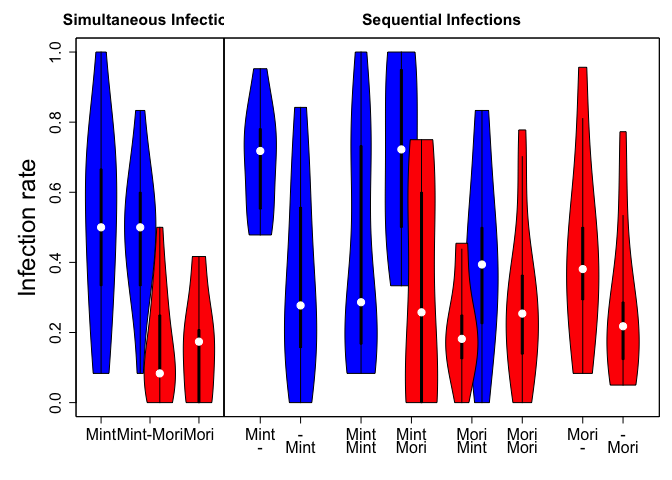

## PART III: Host dependence of infectivity

Tests whether the source species (mussel or oyster) has an effect on the infectitivity of parasite offspring in both species

```r
parental.mod = glm(cbind(M_Total,(Cop_infiltrated-M_Total))~Treatment, data = dataHostNoMiCG, family = 'binomial')
summary(parental.mod)
```

```
##
## Call:
## glm(formula = cbind(M_Total, (Cop_infiltrated - M_Total)) ~ Treatment,
##     family = "binomial", data = dataHostNoMiCG)
##
## Deviance Residuals:
##     Min       1Q   Median       3Q      Max
## -3.2296  -1.6224  -0.8825   0.8148   5.0613
##
## Coefficients:
##               Estimate Std. Error z value Pr(>|z|)
## (Intercept)     0.4017     0.1369   2.933  0.00335 **
## TreatmentMoCg  -2.1522     0.1885 -11.419  < 2e-16 ***
## TreatmentMoMe  -3.3195     0.2435 -13.632  < 2e-16 ***
## ---
## Signif. codes:  0 '***' 0.001 '**' 0.01 '*' 0.05 '.' 0.1 ' ' 1
##
## (Dispersion parameter for binomial family taken to be 1)
##
##     Null deviance: 456.63  on 50  degrees of freedom
## Residual deviance: 186.61  on 48  degrees of freedom
## AIC: 290.16
##
## Number of Fisher Scoring iterations: 5
```

```r
anova(parental.mod,test = 'LRT')
```

```
## Analysis of Deviance Table
##
## Model: binomial, link: logit
##
## Response: cbind(M_Total, (Cop_infiltrated - M_Total))
##
## Terms added sequentially (first to last)
##
##
##           Df Deviance Resid. Df Resid. Dev  Pr(>Chi)
## NULL                         50     456.63
## Treatment  2   270.02        48     186.61 < 2.2e-16 ***
## ---
## Signif. codes:  0 '***' 0.001 '**' 0.01 '*' 0.05 '.' 0.1 ' ' 1
```

```r
dataHost_Mori = subset(dataHostNoMiCG,dataHostNoMiCG$Treatment != 'Mi')
hostMori.mod = glm(cbind(M_Total,(Cop_infiltrated-M_Total))~Treatment * HostSpecies, data = dataHost_Mori, family = 'binomial')
summary(hostMori.mod)
```

```
##
## Call:
## glm(formula = cbind(M_Total, (Cop_infiltrated - M_Total)) ~ Treatment *
##     HostSpecies, family = "binomial", data = dataHost_Mori)
##
## Deviance Residuals:
##     Min       1Q   Median       3Q      Max
## -2.8652  -1.6343  -0.9588   0.8979   3.7891
##
## Coefficients:
##                                   Estimate Std. Error z value Pr(>|z|)
## (Intercept)                        -1.6792     0.1815  -9.249  < 2e-16 ***
## TreatmentMoMe                      -1.2842     0.3586  -3.582 0.000341 ***
## HostSpeciesM_edulis                -0.1416     0.2591  -0.546 0.584782
## TreatmentMoMe:HostSpeciesM_edulis   0.2220     0.4828   0.460 0.645620
## ---
## Signif. codes:  0 '***' 0.001 '**' 0.01 '*' 0.05 '.' 0.1 ' ' 1
##
## (Dispersion parameter for binomial family taken to be 1)
##
##     Null deviance: 138.63  on 41  degrees of freedom
## Residual deviance: 111.64  on 38  degrees of freedom
## AIC: 192.06
##
## Number of Fisher Scoring iterations: 5
```

Plotting Figure 4

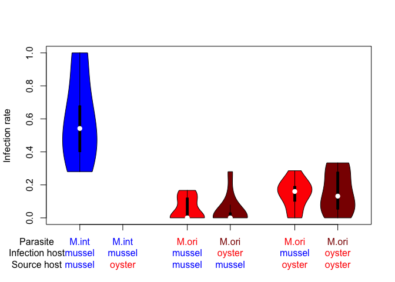

## PART IV: Infection preference

tests whether the prior presence of other con- or heterospecific infections changes the infection choice when offered an infected vs. an uninfected host

```r
# linear model with infection choice parasite species and homologous vs heterologous infection as factor
mod_hom_het = lm(SecondInfection_prop_difference~ FirstIntensity + SecondInfection * hom_het  , data = mytilus_noPreinf)
#anova table
anova(mod_hom_het)
```

```
## Analysis of Variance Table
##
## Response: SecondInfection_prop_difference
##                         Df Sum Sq Mean Sq F value   Pr(>F)
## FirstIntensity           1 0.0061 0.00608  0.0720 0.789893
## SecondInfection          1 0.8918 0.89177 10.5655 0.002416 **
## hom_het                  1 0.0198 0.01979  0.2345 0.631022
## SecondInfection:hom_het  1 0.4427 0.44268  5.2448 0.027654 *
## Residuals               38 3.2073 0.08440
## ---
## Signif. codes:  0 '***' 0.001 '**' 0.01 '*' 0.05 '.' 0.1 ' ' 1
```

```r
summary(mod_hom_het)
```

```
##
## Call:
## lm(formula = SecondInfection_prop_difference ~ FirstIntensity +
##     SecondInfection * hom_het, data = mytilus_noPreinf)
##
## Residuals:
##      Min       1Q   Median       3Q      Max
## -0.72467 -0.17073 -0.03532  0.15615  0.65737
##
## Coefficients:
##                                             Estimate Std. Error t value
## (Intercept)                                 -0.15586    0.09608  -1.622
## FirstIntensity                              -0.01690    0.01082  -1.562
## SecondInfectionOrientalis                    0.53954    0.14015   3.850
## hom_hethomologous                            0.28950    0.13981   2.071
## SecondInfectionOrientalis:hom_hethomologous -0.47510    0.20745  -2.290
##                                             Pr(>|t|)
## (Intercept)                                  0.11304
## FirstIntensity                               0.12659
## SecondInfectionOrientalis                    0.00044 ***
## hom_hethomologous                            0.04524 *
## SecondInfectionOrientalis:hom_hethomologous  0.02765 *
## ---
## Signif. codes:  0 '***' 0.001 '**' 0.01 '*' 0.05 '.' 0.1 ' ' 1
##
## Residual standard error: 0.2905 on 38 degrees of freedom
## Multiple R-squared:  0.2978, Adjusted R-squared:  0.2239
## F-statistic: 4.029 on 4 and 38 DF,  p-value: 0.008053
```

Plot Figure 5

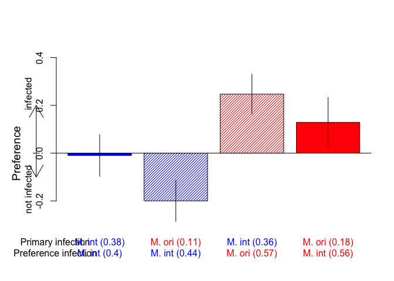